# KMuhammad_HW5 Pt.1

DACSS 601 - HW5: Update and Refinement

Kalimah Muhammad  
2022-04-30

## Update

**Background and Research Questions**  
During the covid-19 pandemic, many businesses, institutions, and organizations across the globe reduced occupancy or closed their doors in an attempt to control the spread of the novel coronavirus, Covid-19. Likewise, schools across the globe made decisions on whether to continue in person learning or adopt distance learning practices. This project will review the status of school closures by country during the 2020-2021 covid-19 pandemic and what characteristics distinguished those who adopted the closures or not.

My research questions include:  
Q1. How did the practice of school closures and re-openings unfold over the pandemic years of 2020 - 2021?  
Q2. What characteristics, if any, by geography, country income level, student to teacher ratio, or access to distance learning modalities could be predictors of adopting similar measures in future events?

The data for this project was procured from UNESCO Institute of Statistics data on COVID-19 Education Response (sourced below). It contains daily school closure status for 210 countries/ territories from 2/16/2020 to 3/31/2022.

## School Closures and Reopenings

**Q1: How did the practice of school closures and reopenings unfold over the pandemic years of 2020 - 2021?** To answer this question, I will review the daily status updates globally, regionally and by country.

### Global School Status

To begin, I summarized all of the variables in the school status column. This includes the daily status updates for each country from 2/16/2020 - 3/31/2022.

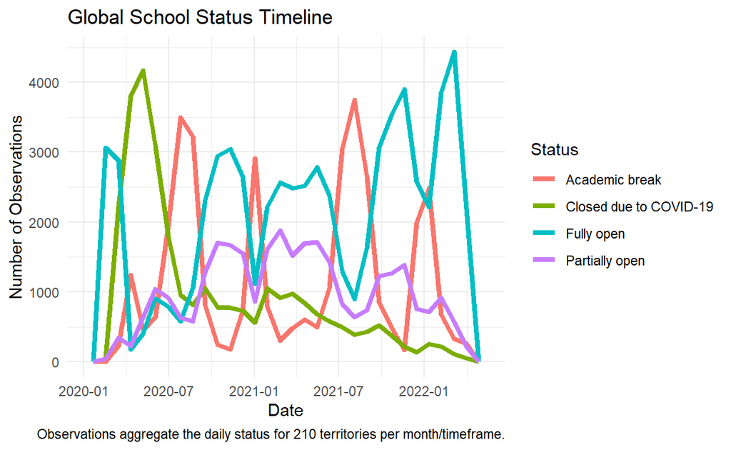

```r
#timeline of global school status
unesco_fin %>%
  group_by(`Country`)%>%
  ggplot(aes(Date,color = `Status`, stat= "identity"))+
  geom_freqpoly(size = 1.5)+
  theme_minimal()+
  labs(title = "Global School Status Timeline",
       caption = "Observations aggregate the daily status for 210 territories per month/timeframe.")+
  ylab("Number of Observations")
```

```r
#total number of observations by global school status
table(unesco_fin$Status)
```

```
        Academic break Closed due to COVID-19             Fully open
                 36534                  29038                  66554
        Partially open
                 30624
```

Percentage of school status to total observations are:  
* Academic break- 22.44793  
* Fully open- 40.89339  
* Partially open- 18.81659  
* Closed due to COVID-19- 17.84209

**Observation**: At a glance, we see proportionately that schools were primarily fully open (41%) or on seasonal academic break (22%) of the time during this 2 year period. School closures due to covid account for approximately 18% of the observations while time partially open accounting for 19%. This suggests that globally schools experienced more time operational (63%) than disrupted by the pandemic (37%).

The first recorded country to close schools due to Covid-19 was Mongolia on 2/16/2020 followed by China 5 days later on 2/21. Three more countries followed in February, San Marino on 2/24 and Iran and Bahrain on 2/26. By the end of March, 189 countries recorded a closure due to the pandemic. By September 30, 2020, 41 countries were fully closed, 55 returned to partially open, 18 were on academic break and 96 were fully open. Over the next 18 months, many territories increasing returned to fully open alternating with pre-planned academic breaks and partial openings. Dips and peaks appear to primarily be caused by academic schedule suggesting regional trends as an area of interest. The remaining countries recorded as closed due to covid as of 3/31/22 (the end of the data set) included: Honduras, the Philippines, Solomon Islands, and Vanuatu.

Additional steps: There are peaks of partially open that could be attributed to seasonality or variant spikes. An additional step could be to overlay a variant spike timeline.

### Regional School Status

Next, I distinguished the school status by region.

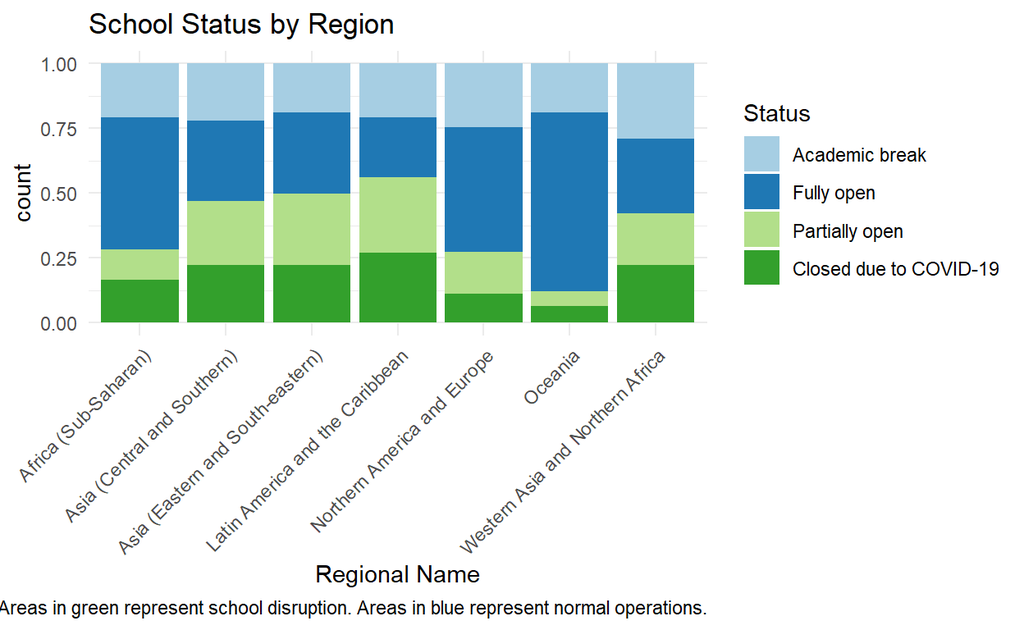

```r
unesco_fin$Status <- factor(unesco_fin$Status, levels=c("Academic break", "Fully open","Partially open", "Closed due to COVID-19"))

unesco_fin %>%
  ggplot(aes(`Regional Name`, fill=`Status`))+
  geom_bar(position = "fill")+
  guides(x = guide_axis(angle= 45))+
  theme_minimal()+
  scale_fill_brewer(palette = "Paired")+
  labs(title = "School Status by Region", caption= "Areas in green represent school disruption. Areas in blue represent normal operations.")
```

**Observation**: In this chart we see a representation of school status during the pandemic. Observations in green (both light and dark) display the percentage of time a region experienced disruption while values in blue (both light and dark) show typical school statuses of fully open or on regular academic break. The Oceania region had the least disruption followed by Sub-Saharan Africa and Northern America/Europe. Latin America and the Caribbean had the highest level of disruption (over 50%) followed by Eastern and South-eastern Asia. This chart suggest that *geographical location likely has a role in school closure status*.

Next I looked specifically at the observations of *Closed due to COVID-19*.

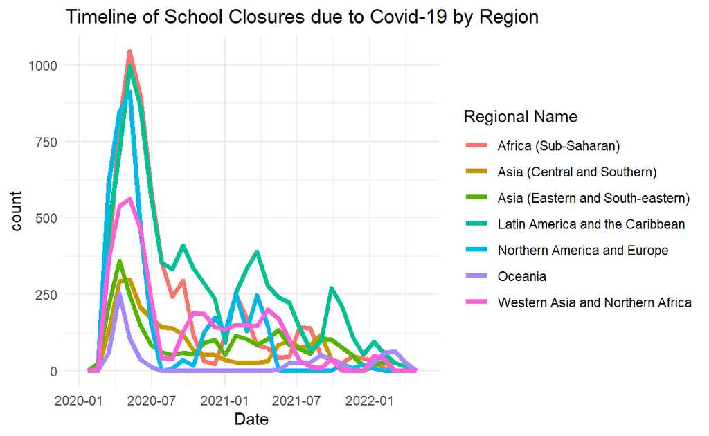

```r
unesco_fin %>%
  filter(`Status` == "Closed due to COVID-19")%>%
  ggplot(aes(Date,color = `Regional Name`, stat= "identity"))+
  geom_freqpoly(size=1.5)+
  theme_minimal()+
  labs(title = "Timeline of School Closures due to Covid-19 by Region")
```

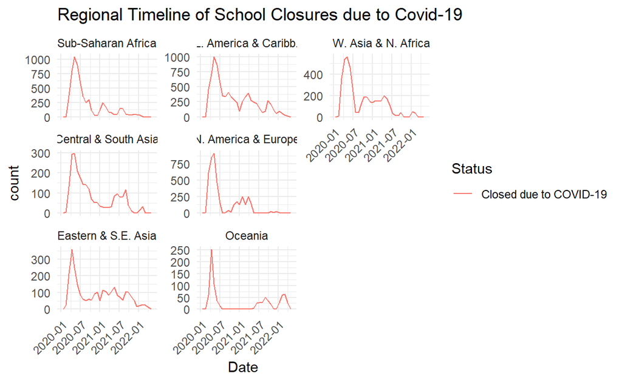

```r
#facet grid of school status timeline
unesco_fin %>%
  filter(`Status` == "Closed due to COVID-19")%>%
  ggplot(aes(Date,color = `Status`))+
  geom_freqpoly()+
  facet_wrap(vars(`Regional Name`), scales = 'free_y', dir="v",
             labeller = labeller(`Regional Name` = c(
               "Africa (Sub-Saharan)" = "Sub-Saharan Africa",
               "Asia (Central and Southern)" = "Central & South Asia",
               "Asia (Eastern and South-eastern)" = "Eastern & S.E. Asia",
               "Latin America and the Caribbean" = "L. America & Caribb.",
               "Northern America and Europe" = "N. America & Europe",
               "Oceania" = "Oceania",
               "Western Asia and Northern Africa" = " W. Asia & N. Africa")))+
  theme_minimal()+
  guides(x = guide_axis(angle= 45))+
  labs(title = "Regional Timeline of School Closures due to Covid-19")
```

**Observation**: Here we see school closures peaked during the first four months of the pandemic beginning in March with a significant decline beginning in July. Over the next 21 months, time fully closed vary within each region. This could be attributed to periods of academic break or peaks in cases and/or deaths in the region. The next chart shows school status changes per region.

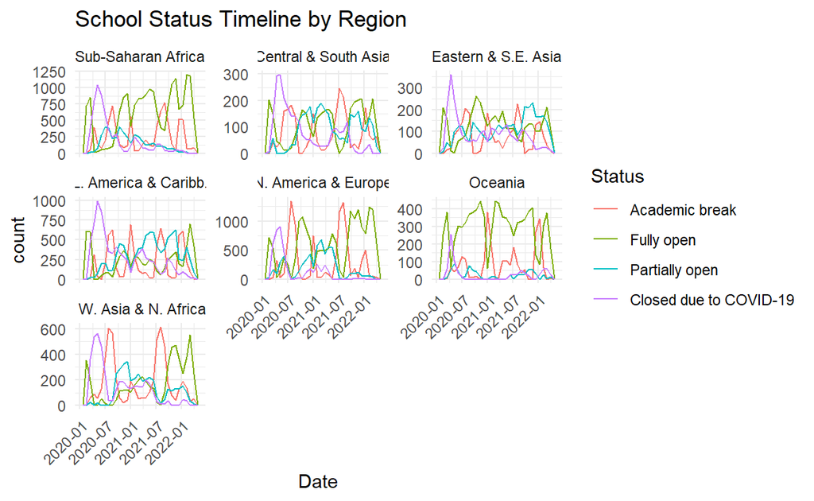

```r
#facet grid of school status timeline
unesco_fin %>%
  ggplot(aes(Date,color = `Status`))+
  geom_freqpoly()+
  facet_wrap(vars(`Regional Name`), scales = 'free_y',
             labeller = labeller(`Regional Name` = c(
               "Africa (Sub-Saharan)" = "Sub-Saharan Africa",
               "Asia (Central and Southern)" = "Central & South Asia",
               "Asia (Eastern and South-eastern)" = "Eastern & S.E. Asia",
               "Latin America and the Caribbean" = "L. America & Caribb.",
               "Northern America and Europe" = "N. America & Europe",
               "Oceania" = "Oceania",
               "Western Asia and Northern Africa" = " W. Asia & N. Africa")))+
  guides(x = guide_axis(angle= 45))+
  theme_minimal()+
  labs(title = "School Status Timeline by Region")
```

**Observation**: In the charts above, we see can see distinct trends by region after the peak closures in March - July 2020. In *Sub-Saharan Africa and Oceania*, regions primarily alternated between fully open and academic break after July highlighting limited disruption in those following months. In *Western Asia and Northern Africa* as well as *Northern America and Europe*, this trend did not return until July 2021 after about a year of being partially open and some extended closures. Finally in *Latin American/ Caribbean*, *Central/Southern Asia*, and *Eastern/South-eastern Asia*, regions varied in partial openings and fully open with peaks of partially open around September 2021.

### Country School Status by Region

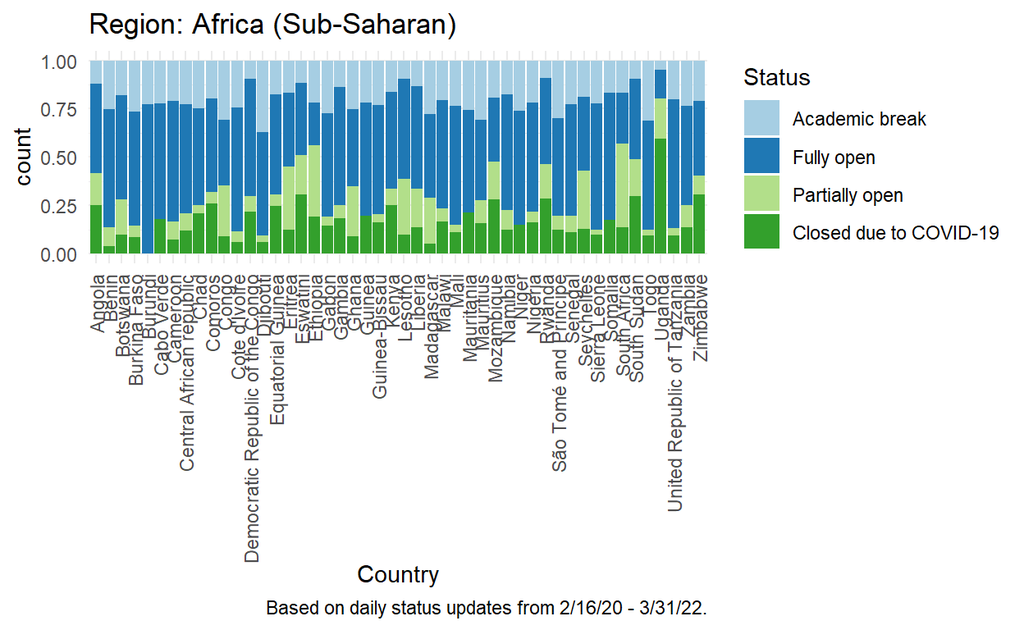

```r
unesco_fin %>%
  filter(`Regional Name` == "Africa (Sub-Saharan)")%>%
  ggplot(aes(Country, fill=`Status`))+
  geom_bar(position = "fill")+
  guides(x = guide_axis(angle= 90))+
  theme_minimal()+
  scale_fill_brewer(palette = "Paired")+
  labs(title = "Region: Africa (Sub-Saharan)", caption = "Based on daily status updates from 2/16/20 - 3/31/22.")
```

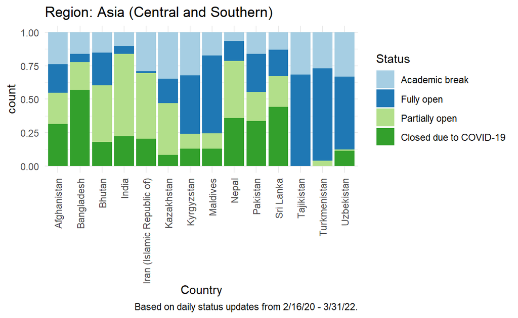

```r
unesco_fin %>%
  filter(`Regional Name` == "Asia (Central and Southern)")%>%
  ggplot(aes(Country, fill=`Status`))+
  geom_bar(position = "fill")+
  guides(x = guide_axis(angle= 90))+
  theme_minimal()+
  scale_fill_brewer(palette = "Paired")+
  labs(title = "Region: Asia (Central and Southern)", caption = "Based on daily status updates from 2/16/20 - 3/31/22.")
```

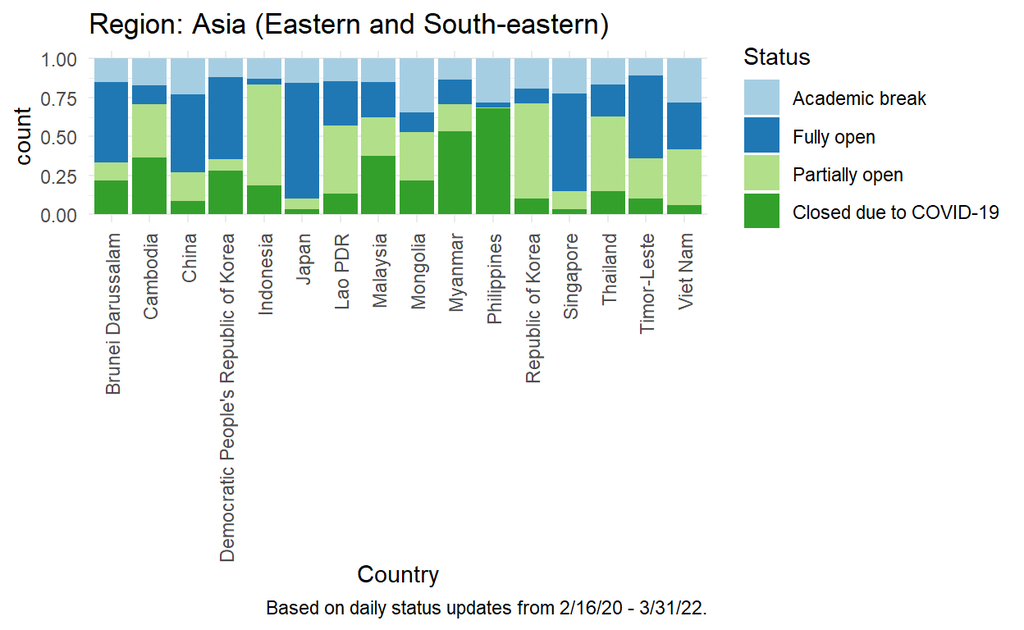

```r
unesco_fin %>%
  filter(`Regional Name` == "Asia (Eastern and South-eastern)")%>%
  ggplot(aes(Country, fill=`Status`))+
  geom_bar(position = "fill")+
  guides(x = guide_axis(angle= 90))+
  theme_minimal()+
  scale_fill_brewer(palette = "Paired")+
  labs(title = "Region: Asia (Eastern and South-eastern)", caption = "Based on daily status updates from 2/16/20 - 3/31/22.")
```

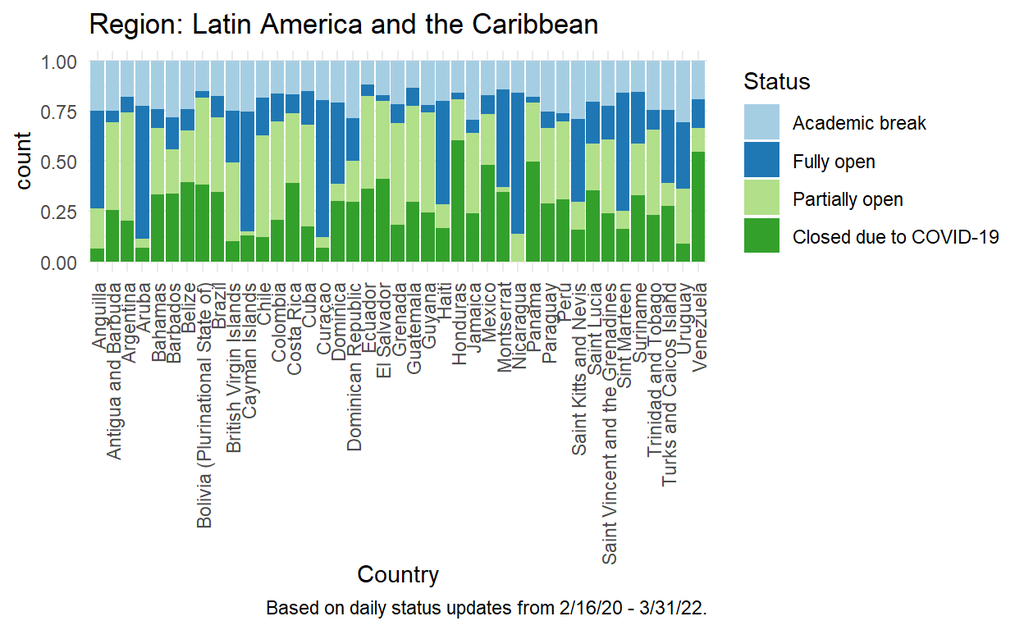

```r
unesco_fin %>%
  filter(`Regional Name` == "Latin America and the Caribbean")%>%
  ggplot(aes(Country, fill=`Status`))+
  geom_bar(position = "fill")+
  guides(x = guide_axis(angle= 90))+
  theme_minimal()+
  scale_fill_brewer(palette = "Paired")+
  labs(title = "Region: Latin America and the Caribbean", caption = "Based on daily status updates from 2/16/20 - 3/31/22.")
```

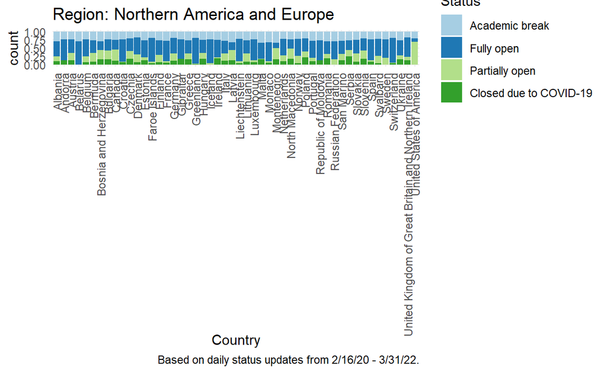

```r
unesco_fin %>%
  filter(`Regional Name` == "Northern America and Europe")%>%
  ggplot(aes(Country, fill=`Status`))+
  geom_bar(position = "fill")+
  guides(x = guide_axis(angle= 90))+
  theme_minimal()+
  scale_fill_brewer(palette = "Paired")+
  labs(title = "Region: Northern America and Europe", caption = "Based on daily status updates from 2/16/20 - 3/31/22.")
```

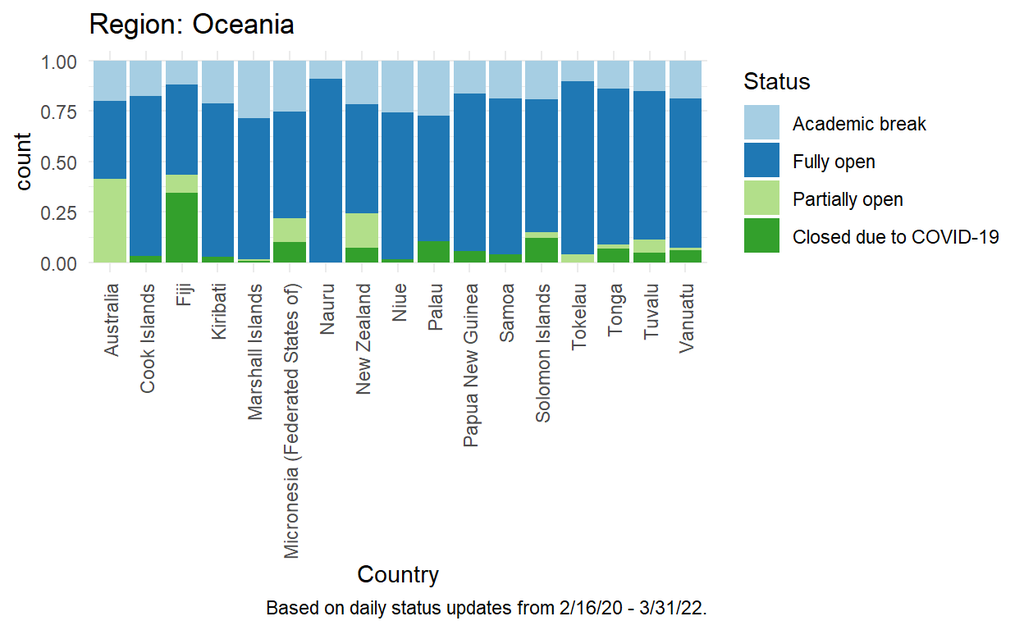

```r
unesco_fin %>%
  filter(`Regional Name` == "Oceania")%>%
  ggplot(aes(Country, fill=`Status`))+
  geom_bar(position = "fill")+
  guides(x = guide_axis(angle= 90))+
  theme_minimal()+
  scale_fill_brewer(palette = "Paired")+
  labs(title = "Region: Oceania", caption = "Based on daily status updates from 2/16/20 - 3/31/22.")
```

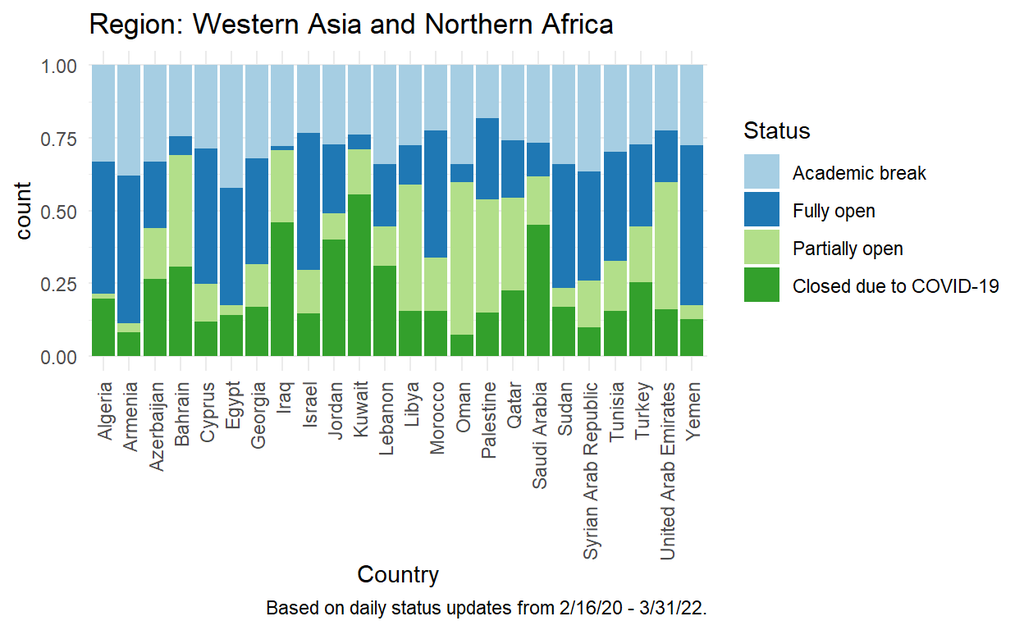

```r
unesco_fin %>%
  filter(`Regional Name` == "Western Asia and Northern Africa")%>%
  ggplot(aes(Country, fill=`Status`))+
  geom_bar(position = "fill")+
  guides(x = guide_axis(angle= 90))+
  theme_minimal()+
  scale_fill_brewer(palette = "Paired")+
  labs(title = "Region: Western Asia and Northern Africa", caption = "Based on daily status updates from 2/16/20 - 3/31/22.")
```

**Observation**: Here we can see further trends within each region. In Oceania, most countries experienced minimal disruption returning quickly to fully open with few exceptions such as Australia and Fiji who remaining closed or partially open for nearly half the time under observation. In Latin America and the Caribbean, there are high levels of partial openings and fully closed countries with the exceptions of such as Aruba, Cayman Islands, Curacao, and Nicaragua. In all three regions of Asia, there are high and frequent levels of partial openings. A few exceptions include Armenia, Japan, Tajikistan, Turkmenistan, Singapore, and Uzbekistan.

Countries that did not fully or partially close due to covid include: Belarus, Burundi, Nauru, and Tajikistan. Countries that experienced only a partial closure include: Australia, Iceland, Nicaragua, Sweden, Turkmenistan, and United States.

### Q1 Conclusion

How did the practice of school closures and re-openings unfold over the pandemic years of 2020 - 2021? After the globe spike between March and July 2020, school closures and reopenings appear to trend regionally. This may be attributed to regional academic calendars or localized spikes in covid variants. However, there are a few exceptions in each region that significantly vary in exceptionally long closures and very limited closing, such as Uganda and Burundi in Sub-Saharan Africa, Bangladesh and Tajikistan in Central and Southern Asia, Japan and the Philippines in Eastern/South-eastern Asia, or Nicaragua and Honduras in Latin American and the Caribbean.

In Part 2 I will look at specific characteristics in country income level, student to teacher ratio, and access to distance learning modalities as potential indicators for this variation.

**Source** UNESCO map on school closures [https://en.unesco.org/covid19/educationresponse] and UIS, March 2022 [http://data.uis.unesco.org]

Comment on this article Share: